# Python Object Orientation Workshop

Paul Chambers

P.R.Chambers@soton.ac.uk

[figure not shown]

## Prerequisites

- Python 3, IPython 4+ (Jupyter Notebook)
- Numpy, Matplotlib
- Download material and exercises from github: https://github.com/p-chambers/Python_OOP_Workshop

```python
# Run this cell before trying examples
import numpy as np
import matplotlib.pyplot as plt
%matplotlib inline
```

# Intro to Python OOP

#### (For The Classy Programmer)

> "Object-oriented programming (OOP) refers to a type of computer programming in which programmers define not only the data type of a data structure, but also the types of operations (functions) that can be applied to the data structure."

Source: [Webopedia](http://www.webopedia.com/TERM/O/object_oriented_programming_OOP.html)

## Why OOP?

- Naturally structured data
- Functions used in context
- Reduce duplicate code
- Maintainability in large codes/software
- [Many other reasons](http://inventwithpython.com/blog/2014/12/02/why-is-object-oriented-programming-useful-with-an-role-playing-game-example/)

### OOP in Scientific Computing

- Java, `C++` and Python designed for OOP
- **Everything** in Python is an object
- Scientific libraries, visualisation tools etc.
- Pseudo Object Orientation in `C` and `Fortran`

### How can this course help me

- Language in OOP is very different
  - Learn language used in eg. C++, Java
- Ability to **read** code is essential
- Write/migrate code for community library
  - Better world! Work recognition etc...

### Language: Four Fundamental Concepts

- *Inheritance*
  - Reuse code by deriving from existing classes
- *Encapsulation*
  - Data hiding

### Language: Four Fundamental Concepts (2)

- *Abstraction*
  - Simplified representation of complexity
- *Polymorphism*
  - API performs differently based on data type

### Material we will cover

- `Classes`
- Initialization and `__init__`
- `self`
- Encapsulation with underscore '`_`'
- Inheritance
- Magic operators
- Python 2.X vs 3.X

## Classes: Basics

- Attributes (data)
- Methods (Functions operating on the attributes)
- 'First class citizens': Same rights as core types
  - pass to functions, store as variables etc.

#### Example: Numpy arrays showing how it's done

```python
# Numpy arrays are classes
import numpy as np
a = np.array([0, 1, 6, 8, 12])
print(a.__class__)
print(type(a))
```

```
<class 'numpy.ndarray'>
<class 'numpy.ndarray'>
```

```python
# We want to operate on the array: try numpy cumulative sum function
print(np.cumsum(a))
```

```
[ 0  1  7 15 27]
```

```python
# np.cumsum('helloworld')   # Should we expect this to work?
```

#### Example: Numpy arrays showing how it's done (ctd.)

- We only know what a cumulative sum means for a narrow scope of data types
- Group them together with an object!

```python
# cumsum is a method belonging to a
a.cumsum()
```

```
array([ 0,  1,  7, 15, 27])
```

#### Example: Simple class

- For now, assume all classes defined by: `class ClassName(object)`

```python
class Greeter(object):
    def hello(self):         # Method (more on 'self' later)
        print("Hello World")

agreeter = Greeter()         # 'Instantiate' the class
print(agreeter)
# agreeter.                  # Tab complete?
```

```
<__main__.Greeter object at 0x10e3d4518>
```

```python
# Note that we don't pass an argument to hello!
agreeter.hello()
```

```
Hello World
```

## Classes: Initialisation and `self`

- `__init__` class method
- Called on creation of an instance
- Convention: `self` = instance
- **Implicit passing** of self, **explicit receive**

### What is an "instance"?

- `Class` is like a type
- Instance is a specific realisation of that type
- eg. "Hello World" is an instance of string
- Instances attributes are not shared

### Classes: Initialisation vs Construction

- Initialisation changes the instance when it is made
- ... `__init__` is not *technically* Construction (see: C++)
- `__new__` '*constructs*' the instance before `__init__`
- `__init__` then initialises the content

#### Example: Class Initialisation

```python
class A(object):
    def __init__(self):
        print("Hello")

a_instance = A()
print(type(a_instance))
```

```
Hello
<class '__main__.A'>
```

### Instance attributes and Class attributes

- Instance attributes definition: `self.attribute = value`
- Class attributes defined outside functions (*class scope*)
- Class attributes are shared by all instances
- Be careful with class attributes

#### Example: Defining Instance attributes/methods

```
{'data': array([ 0. ,  0.1,  0.2,  0.3,  0.4,  0.5,  0.6,  0.7,  0.8,  0.9,  1. ])}
```

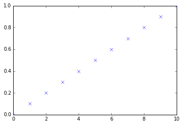

```python
class Container(object):
    """Simple container which stores an array as an instance attribute
    and an instance method"""
    # before we declared class attributes up here ...
    def __init__(self, N):
        self.data = np.linspace(0, 1, N)

    def plot(self):
        fig = plt.figure()
        ax = fig.add_subplot(111)
        ax.plot(self.data, 'bx')

mydata = Container(11)      # 11 ia passed as 'N' to __init__
print(mydata.__dict__)      # __dict__ is where the attr: value
                            #  pairs are stored!
mydata.plot()
```

#### Example: Class attributes vs instance attributes

```python
class Container(object):
    data = np.linspace(0, 1, 5)    # class attribute
    def __init__(self):
        pass

a, b = Container(), Container()
print(a.data)
print(b.data)
```

```
[ 0.    0.25  0.5   0.75  1.  ]
[ 0.    0.25  0.5   0.75  1.  ]
```

```python
a.data = 0                     # Creates INSTANCE attribute
Container.data = 100           # Overwrites CLASS attribute
print(a.data)
print(b.data)
```

```
0
100
```

### Class vs Instance attributes: priority

[figure not shown]

- Source: [toptotal.com](https://www.toptal.com/python/python-class-attributes-an-overly-thorough-guide)

#### Example: Implicit vs Explicit passing Instance

```python
class Container(object):
    def __init__(self, N):
        self.data = np.linspace(0, 1, N)

    def print_data(self):
        print(self.data)

a = Container(11)

a.print_data()          # <<< This is better
Container.print_data(a)
```

```
[ 0.   0.1  0.2  0.3  0.4  0.5  0.6  0.7  0.8  0.9  1. ]
[ 0.   0.1  0.2  0.3  0.4  0.5  0.6  0.7  0.8  0.9  1. ]
```

## Exercise: Basics and Initialisation

Python OOP 1 Basics and Initialisation with images

## Classes: Encapsulation

- Hiding data from users (and developers)
- Use underscores '`_`' or '`__`'
- Useful if data changing should be controlled
- **Convention only in Python** - not enforced!

### Single vs Double Underscore

- Single underscore
  - Nobody outside this class or derived classes should access or change
- Double underscore
  - Stronger attempt to enforce the above
  - Also 'mangles' the attribute name with

`instance._ClassName__Attribute`

#### Example: Data hiding "protected", single underscore

```python
class Fruit(object):
    def __init__(self):
        self._hasjuice = True

    def juice(self):
        if self.isempty(): raise ValueError('No juice!')
        self._hasjuice = False

    def isempty(self):
        return not self._hasjuice

orange = Fruit()
print(orange.isempty())
orange.juice()
print(orange.isempty())
```

```
False
True
```

```python
# orange._                  # tab completion behaviour?
# orange._                 # tab completion behaviour now?
orange._hasjuice = True    # bad!
orange.isempty()
```

```
False
```

#### Example: Data hiding "private", double underscore

```python
class Fruit(object):
    def __init__(self):
        self.__hasjuice = True

    def juice(self):
        if self.isempty(): raise ValueError('No juice!')
        self.__hasjuice = False

    def isempty(self):
        return not self.__hasjuice

apple = Fruit()
```

```python
# apple._                       # tab completion behaviour?
apple.juice()
apple._Fruit__hasjuice = False   # Definitely bad!
apple.isempty()
```

```
True
```

```python
# Live coding Bay....
```

## Classes: Inheritance

- Group multiple objects and methods
- `Child`/`Derived` class inherits from `Parent`/`Base`
- Reduce duplicate code
- Maintanable: changes to base falls through to all
- Beware multiple inheritance rules - we won't cover this

#### Example: Simple inheritance

```python
class Parent(object):
    # Note the base __init__ is overridden in
    # Child class
    def __init__(self):
        pass
    def double(self):
        return self.data*2

class Child(Parent):
    def __init__(self, data):
        self.data = data

achild = Child(np.array([0, 1, 5, 10]))
achild.double()
```

```
array([ 0,  2, 10, 20])
```

#### Example: Calling parent methods with `super`

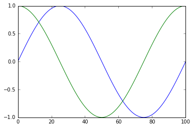

```python
class Plottable(object):
    def __init__(self, data):
        self.data = data
    def plot(self, ax):
        ax.plot(self.data)

class SinWave(Plottable):
    def __init__(self):
        super().__init__(
            np.sin(np.linspace(0, np.pi*2, 101)))

class CosWave(Plottable):
    def __init__(self):
        super().__init__(
            np.cos(np.linspace(0, np.pi*2, 101)))

fig = plt.figure()
ax = fig.add_subplot(111)
mysin = SinWave();   mycos = CosWave()
mysin.plot(ax);      mycos.plot(ax)
```

## Classes: Magic Methods

- The workhorse of how things 'just work' in Python
- `object` & builtin types come with many of these
- Surrounded by double underscores
- We've seen one already: **`__init__`!**

#### Example: The magic methods of object

```python
dir(object)
```

```
['__class__',
 '__delattr__',
 '__dir__',
 '__doc__',
 '__eq__',
 '__format__',
 '__ge__',
 '__getattribute__',
 '__gt__',
 '__hash__',
 '__init__',
 '__le__',
 '__lt__',
 '__ne__',
 '__new__',
 '__reduce__',
 '__reduce_ex__',
 '__repr__',
 '__setattr__',
 '__sizeof__',
 '__str__',
 '__subclasshook__']
```

### Magic Methods: Closer look

- `__lt__`:
  - Called when evaluating

    ```
      a < b
    ```

- `__str__`
  - Called by the print function
- All magics can be overridden

#### Example: overriding `__str__` and `__lt__` magic methods

```python
class Wave(object):
    def __init__(self, freq):
        self.freq = freq
        self._data = np.sin(np.linspace(0, np.pi, 101)
                            * np.pi*2 * freq)

    def __str__(self):
        """RETURNS the string for printing"""
        return "Wave frequency: {}".format(self.freq)

    def __lt__(self, wave2):
        return self.freq < wave2.freq

wav_low = Wave(10)
wav_high = Wave(50)  # A high frequency wave

print(wav_high)
wav_low < wav_high
```

```
Wave frequency: 50
```

```
True
```

```python
# Live coding Bay....
```

## Exercise: Python OOP2: Inheritance and Magic Methods

Python OOP2 Inheritance and Magic Methods using shapes

## Python 2 vs 3

- Dont need to inherit `object` in Python 3
- New classes inherit from `object`
- Inheritance behaviour is different
- Old classes removed in Python 3

#### Example: New class default Python 3

```python
class OldSyntax:
    pass

class NewSyntax(object):  # This means 'inherit from object'
    pass

print(type(OldSyntax))    # Would give <type 'classobj'>
                          # in Python 2
print(type(NewSyntax))
```

```
<class 'type'>
<class 'type'>
```

- Backwards compatibility: inherit `object` in Py3

## Extra Material

- Harder exercise (if time)
- Should test your knowledge from this course

> Exercise: Predator Prey
- Other things worth looking at (an incredibly biased opinion):
  - [Building Pythonic Packages with setuptools](https://pythonhosted.org/an_example_pypi_project/setuptools.html)
  - [Unit testing with py.test](https://pytest.org/latest/contents.html)
  - [Conda Environments](http://conda.pydata.org/docs/using/envs.html)
  - Play with a visualisation/GUI package!

## Summary

- Covered the language and concepts for Object Orientation (Transferable!)
- OOP Implementation in Python
- `Read` the packages you use daily
- Create maintainable packages for yourself and scientific community

# Thank You

P.R.Chambers@soton.ac.uk